# Example: Singular Value Decomposition of a Grayscale Image

In this example, students will explore singular value decomposition (SVD) applied to an image. [Singular value decomposition (SVD)](https://en.wikipedia.org/wiki/Singular_value_decomposition) is a powerful tool used in many applications, such as image and data compression, signal processing, and machine learning. SVD factors a matrix into a canonical form composed of an orthogonal matrix, a diagonal matrix, and another orthogonal matrix.

> **Learning Objectives**

> By the end of this activity, you should be able to:
> - **Decompose** a grayscale image using singular value decomposition and understand what this mathematical technique reveals about the structure of data. You'll learn how SVD breaks down complex information into simpler, ranked components that capture different amounts of detail.
> - **Reconstruct** the original image from its SVD components, and see how using only the top few singular values and their corresponding vectors can still yield a good approximation of the original image. This will illustrate the concept of data compression and how much information is retained or lost when reducing dimensionality.

This example will help you appreciate how mathematical decomposition techniques can reveal hidden patterns in data and provide efficient ways to represent complex information.

Let's get started! ___

## Setup, Data, and Prerequisites

First, we set up the computational environment by including the `Include.jl` file and loading any needed resources.

> The [`include(...)` command](https://docs.julialang.org/en/v1/base/base/#include) evaluates the contents of the input source file, `Include.jl`, in the notebook's global scope. The `Include.jl` file sets paths, loads required external packages, etc. For additional information on functions and types used in this material, see the [Julia programming language documentation](https://docs.julialang.org/en/v1/).

Let's setup our code environment:

```julia
include(joinpath(@__DIR__, "Include.jl"));
```

In addition to standard Julia libraries, we'll also use [the `VLDataScienceMachineLearningPackage.jl` package](https://github.com/varnerlab/VLDataScienceMachineLearningPackage.jl), check out [the documentation](https://varnerlab.github.io/VLDataScienceMachineLearningPackage.jl/dev/) for more information on the functions, types and data used in this material.

### Data

The [TestImages.jl package](https://github.com/JuliaImages/TestImages.jl) provides a convenient Julia interface for loading [standard named test images](https://en.wikipedia.org/wiki/Standard_test_image) and various other example images. Let's load a grayscale image and use SVD to decompose it into frames.

> **Grayscale images** are arrays that hold floating point values $0.0\leq{a_{ij}}\leq{1.0}$. A value of `0.0` represents black, and `1.0` means white. Thus, we can use [Singular value decomposition (SVD)](https://en.wikipedia.org/wiki/Singular_value_decomposition) to decompose (or factor) an image into components and look at the information contained within each element.

Load the `lake_gray` image from the [TestImages.jl package](https://github.com/JuliaImages/TestImages.jl) and save it in the `img` variable.

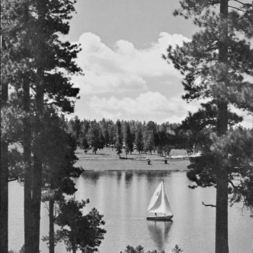

```julia
img = testimage("lake_gray")
```

Next, let's convert the image into grayscale values using the [convert function](https://docs.julialang.org/en/v1/base/base/#Base.convert) in the Julia standard library.

> **Strange syntax alert!** We use the `convert.` syntax to apply the conversion to every image element (similar to using `Gray.` to convert to grayscale). This is called a [vectorized dot operation](https://docs.julialang.org/en/v1/manual/mathematical-operations/#man-dot-operators) that applies a transformation to each element of the array. It's a shortcut instead of writing a loop.

We save the grayscale image matrix in the `image_array` variable.

```julia
image_array = convert.(Float64, Gray.(img)) # convert the image to an array of floats
```

```
512×512 Matrix{Float64}:
 0.145098   0.501961  0.509804  0.458824  …  0.72549   0.709804  0.588235
 0.141176   0.478431  0.513725  0.494118     0.737255  0.713725  0.490196
 0.145098   0.396078  0.411765  0.486275     0.698039  0.65098   0.356863
 0.145098   0.439216  0.396078  0.501961     0.682353  0.517647  0.333333
 0.133333   0.392157  0.396078  0.458824     0.654902  0.47451   0.270588
 0.133333   0.427451  0.423529  0.462745  …  0.686275  0.513725  0.282353
 0.133333   0.454902  0.521569  0.568627     0.623529  0.537255  0.309804
 0.129412   0.537255  0.6       0.666667     0.45098   0.45098   0.27451
 0.0862745  0.619608  0.686275  0.670588     0.392157  0.462745  0.384314
 0.0784314  0.494118  0.607843  0.623529     0.352941  0.501961  0.380392
 ⋮                                        ⋱            ⋮
 0.141176   0.12549   0.152941  0.152941     0.662745  0.635294  0.721569
 0.137255   0.109804  0.172549  0.137255     0.623529  0.678431  0.662745
 0.137255   0.14902   0.14902   0.145098  …  0.658824  0.619608  0.505882
 0.113725   0.137255  0.168627  0.129412     0.639216  0.654902  0.509804
 0.117647   0.109804  0.2       0.109804     0.65098   0.627451  0.501961
 0.105882   0.156863  0.156863  0.101961     0.654902  0.603922  0.529412
 0.0980392  0.14902   0.164706  0.109804     0.631373  0.635294  0.564706
 0.105882   0.188235  0.145098  0.113725  …  0.607843  0.623529  0.54902
 0.105882   0.152941  0.141176  0.133333     0.643137  0.643137  0.564706
```

We now have the `image_array::Array{Float64,2}` matrix, which represents the grayscale values of the image. Each element in the matrix corresponds to a pixel in the image, with values ranging from `0.0` (black) to `1.0` (white).

## Task 1: Let's decompose the image using SVD

In this task, we decompose the image matrix into its singular value components using Singular Value Decomposition (SVD).

> **How?** We'll use the [`svd(...)` method exported from the LinearAlgebra package](https://docs.julialang.org/en/v1/stdlib/LinearAlgebra/#LinearAlgebra.SVD) to compute the singular value decomposition of `image_array::Array{Float64,2}`. We could have written this ourselves, but it's convenient to use the built-in function.

This produces the `U`, `Σ`, and `V` matrices, holding the left singular vectors, the singular values, and the right singular vectors, respectively.

```julia
(U,Σ,V) = svd(image_array); # compute the SVD of the image
```

Let's check some of the properties of the matrices produced by the SVD. First, `U` and `V` are orthogonal matrices.

> **Test:** The columns (or rows, respectively) of `U` and `V` are orthogonal unit vectors. Thus, $\mathbf{U}^\top \mathbf{U} = \mathbf{I}_m$ and $\mathbf{V}^\top \mathbf{V} = \mathbf{I}_n$, i.e., the dot product of any pair of different columns (or rows) is zero, and the dot product of each column (or row) with itself is one. Let's check this by computing the matrix products and comparing with the identity matrix.

In the code block below, we compute the products and check if they are (approximately) equal to the identity matrix using [the @assert macro](https://docs.julialang.org/en/v1/base/base/#Base.@assert) in the Julia standard library. If the assertion fails, [an `AssertionError`](https://docs.julialang.org/en/v1/base/base/#Core.AssertionError) will be raised.

This code [uses the `I(...)` construct](https://docs.julialang.org/en/v1/stdlib/LinearAlgebra/#LinearAlgebra.I) from the LinearAlgebra package to create identity matrices of the appropriate size.

```julia
let

    # compute the product -
    P₁ = transpose(U) * U;
    P₂ = transpose(V) * V;

    # check: both P₁ and P₂ should be identity matrices
    @assert isapprox(P₁, I) && isapprox(P₂, I)
end
```

Next, `Σ` should be a matrix with sorted values (largest to smallest). Is that what we see? Hmmm. Not quite. The default [`svd(...)` method](https://docs.julialang.org/en/v1/stdlib/LinearAlgebra/#LinearAlgebra.SVD) returns a **sorted vector**, not a diagonal matrix.

We can use [the `diagm(...)` method](https://docs.julialang.org/en/v1/stdlib/LinearAlgebra/#LinearAlgebra.diagm) to generate a diagonal matrix `ΣM` from the `Σ` vector.

```julia
ΣM = Σ |> m-> diagm(m) # convert the Σ vector to a diagonal matrix
```

```
512×512 Matrix{Float64}:
 268.108   0.0      0.0     0.0    …  0.0         0.0         0.0
   0.0    51.8105   0.0     0.0       0.0         0.0         0.0
   0.0     0.0     27.922   0.0       0.0         0.0         0.0
   0.0     0.0      0.0    21.077     0.0         0.0         0.0
   0.0     0.0      0.0     0.0       0.0         0.0         0.0
   0.0     0.0      0.0     0.0    …  0.0         0.0         0.0
   0.0     0.0      0.0     0.0       0.0         0.0         0.0
   0.0     0.0      0.0     0.0       0.0         0.0         0.0
   0.0     0.0      0.0     0.0       0.0         0.0         0.0
   0.0     0.0      0.0     0.0       0.0         0.0         0.0
   ⋮                               ⋱              ⋮
   0.0     0.0      0.0     0.0       0.0         0.0         0.0
   0.0     0.0      0.0     0.0       0.0         0.0         0.0
   0.0     0.0      0.0     0.0    …  0.0         0.0         0.0
   0.0     0.0      0.0     0.0       0.0         0.0         0.0
   0.0     0.0      0.0     0.0       0.0         0.0         0.0
   0.0     0.0      0.0     0.0       0.0         0.0         0.0
   0.0     0.0      0.0     0.0       0.00194945  0.0         0.0
   0.0     0.0      0.0     0.0    …  0.0         0.00109472  0.0
   0.0     0.0      0.0     0.0       0.0         0.0         0.000640467
```

If we compute the matrix product $\mathbf{U}\mathbf{Σ}\mathbf{V}^\top$, we should get back our original image matrix (approximately, due to numerical precision issues). Let's check this.

```julia
let
    reconstructed = U * ΣM * transpose(V);
    @assert isapprox(reconstructed, image_array)
end
```

Ok, so our decomposition seems to be correct. Let's move on to the next task. ___

## Task 2: Compute the sub-images and store them in a dictionary

In this task, we turn to the question of what SVD can do for us.

> **Data reduction**

> Singular value decomposition (SVD) can be thought of as decomposing a matrix into a weighted, ordered sum of separable matrices, e.g., frames of a larger image. Let $\mathbf{A}\in\mathbb{R}^{m\times{n}}$ have the singular value decomposition $\mathbf{A} = \mathbf{U}\mathbf{\Sigma}\mathbf{V}^{T}$. Then, the matrix $\mathbf{A}\in\mathbb{R}^{m\times{n}}$ can be written as: $$

\begin{align*} \mathbf{A} &= \sum_{i=1}^{r({\mathbf{A}})}\sigma_{i}\cdot\underbrace{\left(\mathbf{u}_{i}\otimes\mathbf{v}_{i}\right)}_{\mathbf{A}_{i}} \end{align*}

$$

> where $r({\mathbf{A}})$ is the rank of matrix $\mathbf{A}$, the vectors $\mathbf{u}_{i}$ and $\mathbf{v}_{i}$ are the $i$-th left and right singular vectors, and $\sigma_{i}$ are the ordered singular values. The [outer product](https://en.wikipedia.org/wiki/Outer_product) $\mathbf{A}_{i} = \left(\mathbf{u}_{i}\otimes\mathbf{v}_{i}\right)$ is a separable rank-one component of the matrix $\mathbf{A}$.

Ok, so let's do this decomposition and see what this sum looks like. First, we compute the rank $r(\mathbf{A})$ of `image_array` using the [`rank(...)` function](https://docs.julialang.org/en/v1/stdlib/LinearAlgebra/#LinearAlgebra.rank) and then calculate the individual frames $\sigma_{i}\,\mathbf{A}_{i}$ of the image by computing the [outer product](https://en.wikipedia.org/wiki/Outer_product) of the left and right singular vectors.

We use the [foreach iteration pattern](https://docs.julialang.org/en/v1/base/collections/#Base.foreach) as a shortcut means of populating the `image_frames_dictionary` variable. We could have used a regular for loop. But let's go crazy!

```julia
image_frames_dictionary = let

    # initialize -
    image_frames_dictionary = Dict{Int64,Matrix{Gray{Float64}}}();

    R = rank(image_array); # how many frames will we have?
    foreach(i -> image_frames_dictionary[i] = Σ[i]*⊗(U[:,i],V[:,i]), 1:R); # another iteration pattern???

    image_frames_dictionary; # return
end
```

```
Dict{Int64, Matrix{Gray{Float64}}} with 512 entries:
  56  => [0.00146433 0.000268633 … 0.00620922 0.0067289; -0.000937664 -0.000172…
  35  => [0.00544824 0.0941816 … -0.010173 0.00434914; 0.00455488 0.0787383 … -…
  425 => [7.09436e-6 -2.13339e-5 … -3.84133e-5 1.17366e-5; 1.33316e-5 -4.00904e…
  429 => [-2.30386e-5 -1.51501e-5 … -8.91128e-6 5.38801e-5; 2.50756e-5 1.64897e…
  60  => [-0.00215342 -0.00752688 … 0.00146888 -0.0209274; -0.00174363 -0.00609…
  220 => [0.000952013 -3.30509e-6 … -0.00027953 -0.000712395; 0.00114276 -3.967…
  308 => [0.000297533 0.000672352 … 0.000617104 -0.0011678; -7.11045e-5 -0.0001…
  67  => [0.00714474 -0.0410458 … 0.0203699 0.0249557; 0.00742641 -0.0426639 … …
  215 => [-0.000465002 2.12365e-5 … 0.000328727 -6.58782e-5; 0.00182461 -8.3329…
  73  => [0.0039525 0.0117602 … 0.00283073 0.0044022; 0.00339485 0.010101 … 0.0…
  319 => [-1.83005e-5 2.86602e-5 … 0.000169633 -8.72264e-5; -4.59417e-5 7.19489…
  251 => [-6.39536e-5 -9.08434e-5 … -0.000110712 3.04505e-5; 0.000133281 0.0001…
  115 => [-0.0003643 0.000615256 … 0.00143523 -0.000788956; -0.00124872 0.00210…
  112 => [-0.000251039 0.00246403 … 0.00149501 0.00102977; -0.000818022 0.00802…
  185 => [-0.000433481 -0.00062557 … -0.00197735 -0.000993249; 0.000537139 0.00…
  348 => [0.0003786 0.000311492 … 0.000593259 -0.000418635; 0.000668934 0.00055…
  420 => [5.46312e-5 5.96053e-5 … 5.66088e-5 -6.42526e-5; -0.000100906 -0.00011…
  404 => [-0.000287309 -4.21301e-5 … 0.000391841 0.00011189; 2.27569e-5 3.337e-…
  365 => [5.272e-5 5.18452e-6 … -7.47932e-6 1.32846e-5; -0.000654625 -6.43762e-…
  ⋮   => ⋮
```

What is the rank of the `image_array::Array{Float64,2}`? The rank is given by the number of non-zero singular values in its singular value decomposition (SVD).

```julia
R = rank(image_array)
```

```
512
```

### Not every frame contains the same amount of information

One of the cool things about [singular value decomposition](https://en.wikipedia.org/wiki/Singular_value_decomposition) is that frames are sorted and weighted by the singular values. Thus, we can compute the contribution of each frame by looking at the singular values.

Let's compute and visualize how much information, i.e., what fraction of the original image, is explained by each frame by looking at the cumulative sum.

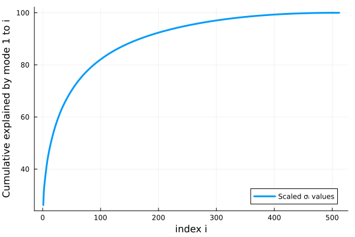

```julia
let

    # make a plot of the fractional contribution of the singular values
    number_of_modes = length(Σ);
    ΣS = (1/sum(Σ))*Σ;
    explained_array = [100*sum(ΣS[1:i]) for i ∈ 1:number_of_modes]; # comprehension

    plot(explained_array, label="Scaled σᵢ values", lw=3)
    xlabel!("index i", fontsize=18)
    ylabel!("Cumulative explained by mode 1 to i", fontsize=18)
end
```

### Can we reconstruct the original image by adding up all the frames?

Let's try to rebuild the original image by adding up the frames. Since the original image is just a matrix, we can use the structural decomposition idea to do this.

> **Idea:** Grab the first frame from the `image_frames_dictionary` and set this to the `M` variable. Then, iterate through the collection up to a specified `number_of_frames`, where we update the `M` variable each time through the loop with the next frame. This should reconstruct the original image, one rank unit at a time. Mind blown!

So what do we see?

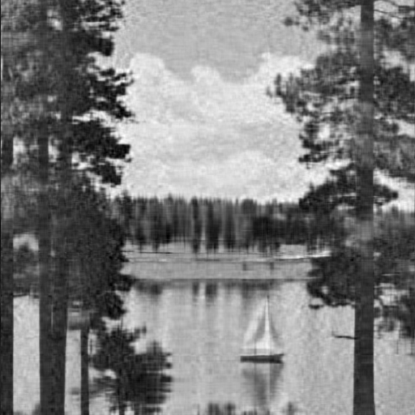

```julia
M = image_frames_dictionary[1];
number_of_frames = 40;
for i ∈ 2:number_of_frames
    M += image_frames_dictionary[i]
end
M # this will show the reconstructed image
```

### What is the rank of the matrix blocks being added together?

Recall that the rank of a matrix is the number of linearly independent rows (or columns) in a matrix. Singular value decomposition gives us another way to think about rank: it is a measure of the unique information held by the matrix, i.e., the number of rank-one blocks!

> **Idea.** Let's check out this alternative notion of rank. If we reconstruct the matrix by adding rank-one blocks together, the rank of the resulting matrix will be equal to the number of linearly independent blocks being added, i.e., the `number_of_frames` variable that we specified.

Let's check this by computing the rank of the `M` matrix using [the `@assert` macro](https://docs.julialang.org/en/v1/base/base/#Base.@assert).

```julia
@assert rank(M) == number_of_frames
```

Wow! ___

## Summary

In this example, we learned how SVD breaks down complex matrices into ranked components that reveal the underlying structure of information.

> **Key Takeaways:**
> - **SVD Reveals Data Structure**: SVD decomposes any matrix into three parts ($\mathbf{U}$, $\mathbf{\Sigma}$, $\mathbf{V}$) where the singular values are ranked by importance, showing us which components contain the most essential information.
> - **Efficient Data Compression**: We can reconstruct recognizable images using only the most important components, dramatically reducing storage requirements while preserving key visual features.
> - **Rank Equals Information Content**: The rank of a matrix tells us how many independent pieces of information it contains, and SVD gives us these pieces in order of significance.

Through this hands-on exploration, we verified SVD's mathematical properties and demonstrated how rank-one components can reconstruct complex data.